# Soluciones P3: Pruebas de t en R

**Soluciones P3:**  
Pruebas de t en `R`

Marta Coronado Zamora Octubre 2026

En estas soluciones leemos los ficheros desde la carpeta `data`. Si usas el enlace URL (`https://raw.githubusercontent.com/marta-coronado/biostatistics-uab/refs/heads/main/P/3/data/...`), el resultado es exactamente el mismo.

# `t`-test de muestras independientes: ToothGrowth

### Leer los datos

```r
dientes <- read.table("data/ToothGrowth.txt", header = TRUE, sep = "\t")
head(dientes)
```

```
##    len supp dose
## 1  4.2   VC  0.5
## 2 11.5   VC  0.5
## 3  7.3   VC  0.5
## 4  5.8   VC  0.5
## 5  6.4   VC  0.5
## 6 10.0   VC  0.5
```

Nos quedamos con la dosis de 0.5 mg/día:

```r
dientes_0.5 <- dientes %>% filter(dose == 0.5)
dientes_0.5
```

```
##     len supp dose
## 1   4.2   VC  0.5
## 2  11.5   VC  0.5
## 3   7.3   VC  0.5
## 4   5.8   VC  0.5
## 5   6.4   VC  0.5
## 6  10.0   VC  0.5
## 7  11.2   VC  0.5
## 8  11.2   VC  0.5
## 9   5.2   VC  0.5
## 10  7.0   VC  0.5
## 11 15.2   OJ  0.5
## 12 21.5   OJ  0.5
## 13 17.6   OJ  0.5
## 14  9.7   OJ  0.5
## 15 14.5   OJ  0.5
## 16 10.0   OJ  0.5
## 17  8.2   OJ  0.5
## 18  9.4   OJ  0.5
## 19 16.5   OJ  0.5
## 20  9.7   OJ  0.5
```

### 1. Comprobación de normalidad

Extraemos el vector de `len` de cada grupo:

```r
len_OJ <- dientes_0.5 %>% filter(supp == "OJ") %>% pull(len)
len_VC <- dientes_0.5 %>% filter(supp == "VC") %>% pull(len)

shapiro.test(len_OJ)
```

```
##
##  Shapiro-Wilk normality test
##
## data:  len_OJ
## W = 0.89274, p-value = 0.182
```

```r
shapiro.test(len_VC)
```

```
##
##  Shapiro-Wilk normality test
##
## data:  len_VC
## W = 0.89, p-value = 0.1696
```

En los dos grupos p > 0.05: no rechazamos H₀ (normalidad). No tenemos evidencia de que los datos no sigan una distribución normal.

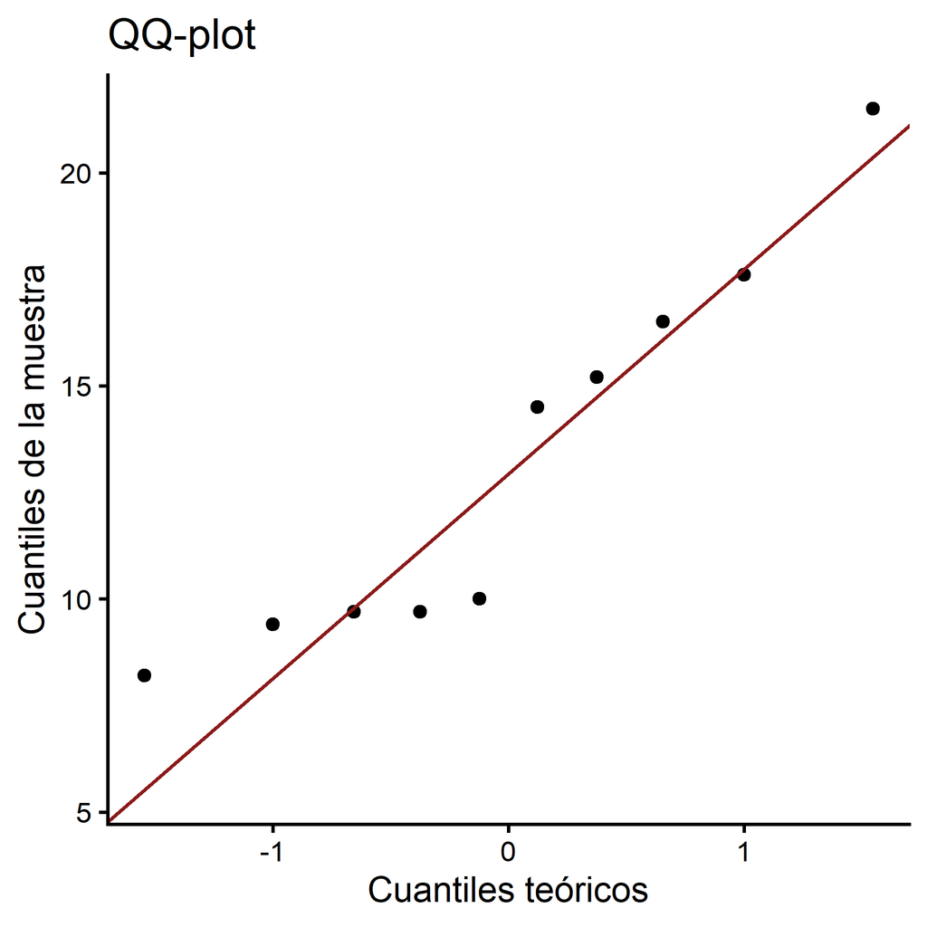

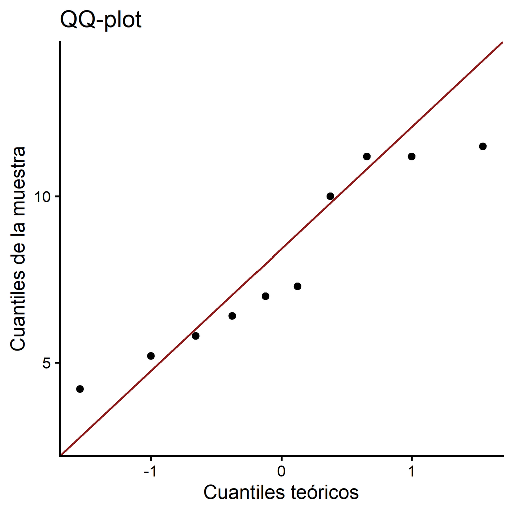

```r
QQ_plot(len_OJ)
QQ_plot(len_VC)
```

Los puntos siguen razonablemente bien la recta en los dos grupos (con solo 10 datos por grupo, es normal que se separen un poco en los extremos).

### 2. Homogeneidad de varianzas

```r
leveneTest(len ~ supp, data = dientes_0.5)
```

```
## Levene's Test for Homogeneity of Variance (center = median)
##       Df F value  Pr(>F)
## group  1  3.3804 0.08253 .
##       18
## ---
## Signif. codes:  0 '***' 0.001 '**' 0.01 '*' 0.05 '.' 0.1 ' ' 1
```

p = 0.083 > 0.05: no rechazamos H₀ (varianzas iguales). Podemos usar `var.equal = TRUE`.

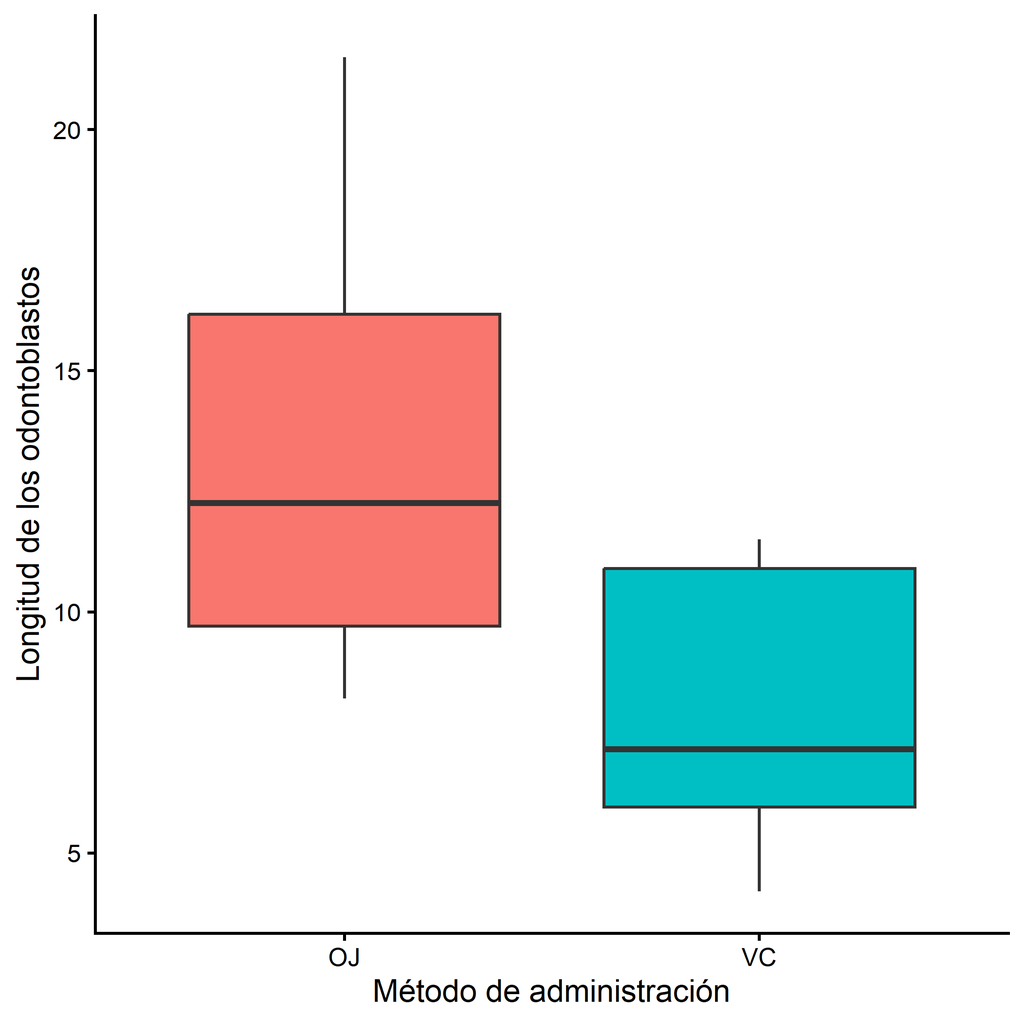

```r
ggplot(dientes_0.5, aes(x = supp, y = len, fill = supp)) +
  geom_boxplot() +
  theme_classic() +
  theme(legend.position = "none") +
  labs(x = "Método de administración", y = "Longitud de los odontoblastos")
```

El grupo `OJ` tiene algo más de dispersión que `VC`, pero el test de Levene no encuentra diferencias significativas.

### 3. `t`-test

```r
t.test(len ~ supp, data = dientes_0.5, var.equal = TRUE)
```

```
##
##  Two Sample t-test
##
## data:  len by supp
## t = 3.1697, df = 18, p-value = 0.005304
## alternative hypothesis: true difference in means between group OJ and group VC is not equal to 0
## 95 percent confidence interval:
##  1.770262 8.729738
## sample estimates:
## mean in group OJ mean in group VC
##            13.23             7.98
```

- **Hipótesis:** H₀: $\mu_{OJ} = \mu_{VC}$ (el método de administración no afecta a la longitud media de los odontoblastos); H₁: $\mu_{OJ} \neq \mu_{VC}$.
- Es un test **bilateral** (`alternative hypothesis: ... not equal to 0`).
- p = 0.0053 < 0.05: rechazamos H₀. Con una dosis de 0.5 mg/día, la longitud media de los odontoblastos es mayor con zumo de naranja (13.23) que con ácido ascórbico (7.98).

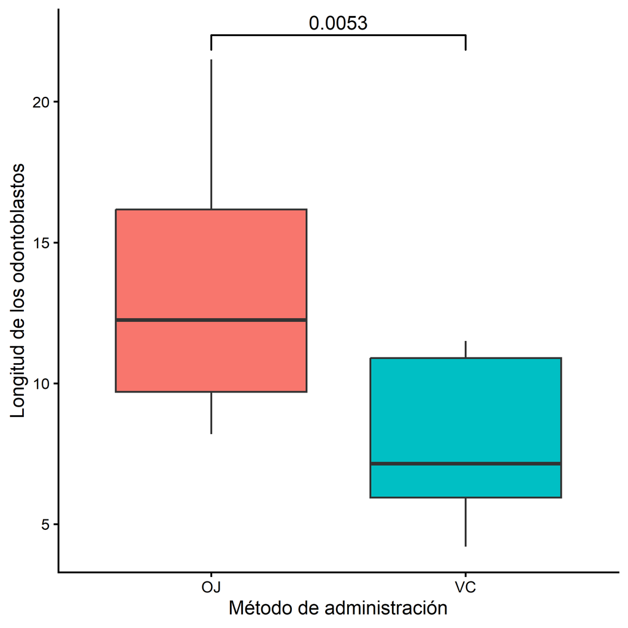

```r
ggplot(dientes_0.5, aes(x = supp, y = len, fill = supp)) +
  geom_boxplot() +
  theme_classic() +
  theme(legend.position = "none") +
  labs(x = "Método de administración", y = "Longitud de los odontoblastos") +
  geom_signif(comparisons = list(c("OJ", "VC")),
              test = "t.test", test.args = list(var.equal = TRUE))
```

### 4. Tamaño del efecto: *d* de Cohen

```r
cohens_d(len ~ supp, data = dientes_0.5)
```

```
## Cohen's d |       95% CI
## ------------------------
## 1.42      | [0.41, 2.39]
##
## - Estimated using pooled SD.
```

*d* = 1.42 ≥ 0.8: es un **efecto grande**. Las medias de los dos grupos están separadas más de una desviación típica. Pero el IC 95% es muy ancho (0.41–2.39): con 10 cobayas por grupo, el efecto real podría ir de pequeño-medio a enorme.

Guardamos el valor de *d* en el objeto `d` para usarlo después (también puedes copiar el número directamente: `d <- 1.42`):

```r
d <- cohens_d(len ~ supp, data = dientes_0.5)$Cohens_d
d
```

```
## [1] 1.417548
```

### 5. Potencia estadística

**a) Potencia del experimento:**

`power.t.test()` solo utiliza el cociente `delta / sd`, que es la *d* de Cohen. Por eso hay dos maneras equivalentes de darle los datos:

| Unidades | `delta` | `sd` | En este ejemplo |
| --- | --- | --- | --- |
| **Desviaciones típicas** | *d* de Cohen | `1` | `delta = 1.42`, `sd = 1` |
| **Unidades reales** (µm) | diferencia de medias $\bar{x}_{OJ} - \bar{x}_{VC}$ | desviación típica combinada $s_p$ | `delta = 5.25`, `sd = 3.70` |

En los dos casos, `delta / sd` $= 5.25 / 3.70 = 1.42 = d$.

```r
power.t.test(n = 10, delta = d, sd = 1, sig.level = 0.05)
```

```
##
##      Two-sample t test power calculation
##
##               n = 10
##           delta = 1.417548
##              sd = 1
##       sig.level = 0.05
##           power = 0.8500908
##     alternative = two.sided
##
## NOTE: n is number in *each* group
```

Comprobamos que en las unidades reales (diferencia de medias y $s_p$) da exactamente lo mismo:

```r
dif_medias <- mean(len_OJ) - mean(len_VC)
s_p <- sqrt(((length(len_OJ) - 1) * var(len_OJ) + (length(len_VC) - 1) * var(len_VC)) /
            (length(len_OJ) + length(len_VC) - 2))
c(dif_medias = dif_medias, s_p = s_p, d = dif_medias / s_p)
```

```
## dif_medias        s_p          d
##   5.250000   3.703579   1.417548
```

```r
power.t.test(n = 10, delta = dif_medias, sd = s_p, sig.level = 0.05)
```

```
##
##      Two-sample t test power calculation
##
##               n = 10
##           delta = 5.25
##              sd = 3.703579
##       sig.level = 0.05
##           power = 0.8500908
##     alternative = two.sided
##
## NOTE: n is number in *each* group
```

La potencia era de 0.85: con 10 cobayas por grupo, el experimento tenía un 85% de probabilidad de detectar una diferencia de este tamaño.

**b) *n* necesaria para una potencia del 80% y del 90%:**

```r
power.t.test(delta = d, sd = 1, sig.level = 0.05, power = 0.8)
```

```
##
##      Two-sample t test power calculation
##
##               n = 8.883187
##           delta = 1.417548
##              sd = 1
##       sig.level = 0.05
##           power = 0.8
##     alternative = two.sided
##
## NOTE: n is number in *each* group
```

```r
power.t.test(delta = d, sd = 1, sig.level = 0.05, power = 0.9)
```

```
##
##      Two-sample t test power calculation
##
##               n = 11.50918
##           delta = 1.417548
##              sd = 1
##       sig.level = 0.05
##           power = 0.9
##     alternative = two.sided
##
## NOTE: n is number in *each* group
```

*n* = 8.88 → **9 cobayas por grupo** para una potencia del 80%, y *n* = 11.51 → **12 cobayas por grupo** para una potencia del 90% (siempre redondeando hacia arriba).

**¿Tenía suficiente potencia?** Sí: con 10 cobayas por grupo superaba el 80% habitual. Como el efecto es grande, no hacen falta muestras muy grandes para detectarlo.

# `t`-test pareado: peso de ratones

```r
peso_ratones <- read.table("data/peso_ratones.txt", header = TRUE, sep = "\t")
head(peso_ratones)
```

```
##   id grupo  peso
## 1  1 antes 200.1
## 2  2 antes 190.9
## 3  3 antes 192.7
## 4  4 antes 213.0
## 5  5 antes 241.4
## 6  6 antes 196.9
```

```r
antes <- peso_ratones %>% filter(grupo == "antes") %>% pull(peso)
despues <- peso_ratones %>% filter(grupo == "despues") %>% pull(peso)
```

### 1. Comprobación de normalidad

```r
dif <- despues - antes
dif
```

```
##  [1] 192.8 202.3 152.4 180.0 192.6 231.0 249.8 198.4 187.1 158.5
```

```r
shapiro.test(dif)
```

```
##
##  Shapiro-Wilk normality test
##
## data:  dif
## W = 0.94536, p-value = 0.6141
```

p = 0.61 > 0.05: no tenemos evidencia de que las diferencias no sigan una distribución normal.

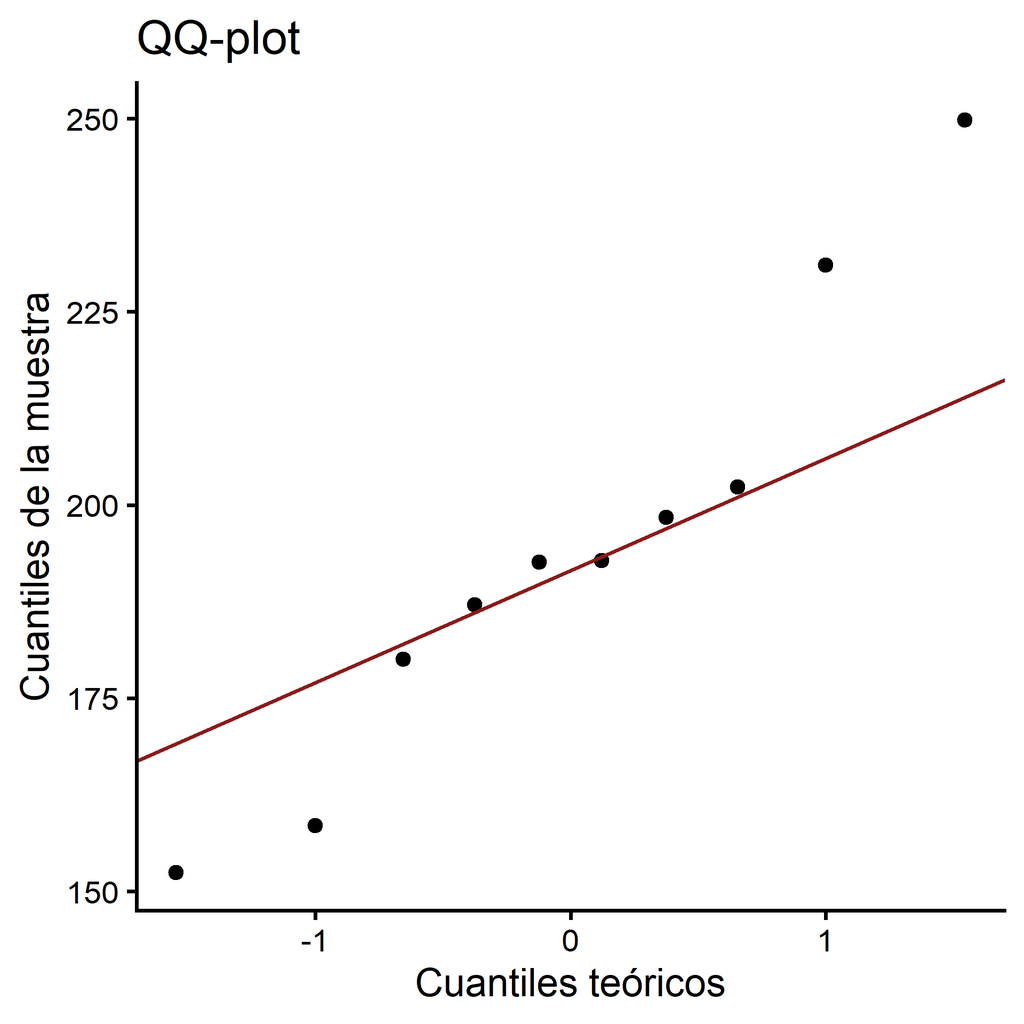

```r
QQ_plot(dif)
```

### 2. Homogeneidad de varianzas

No hace falta: en el `t`-test pareado solo trabajamos con las diferencias.

### 3. `t`-test pareado

```r
t.test(despues, antes, paired = TRUE)
```

```
##
##  Paired t-test
##
## data:  despues and antes
## t = 20.883, df = 9, p-value = 6.2e-09
## alternative hypothesis: true mean difference is not equal to 0
## 95 percent confidence interval:
##  173.4219 215.5581
## sample estimates:
## mean difference
##          194.49
```

- H₀: la diferencia media (después − antes) es 0; H₁: es distinta de 0. Es un test **bilateral**.
- p = 6.2 × 10⁻⁹ < 0.05: rechazamos H₀. Después del tratamiento, los ratones pesan de media 194.5 g más (IC 95%: 173.4–215.6 g).

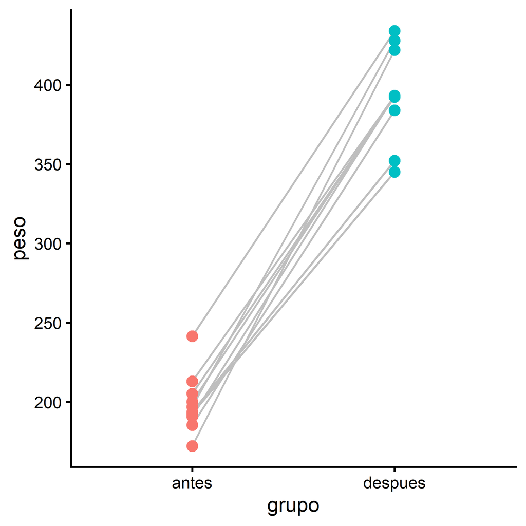

```r
ggplot(peso_ratones, aes(x = grupo, y = peso, group = id)) +
    geom_line(color = "grey") +
    geom_point(aes(color = grupo), size = 3) +
    theme_classic(base_size = 14) +
    theme(legend.position = "none")
```

Todas las líneas suben: todos los ratones aumentan de peso.

### 4. Potencia estadística

En el `t`-test pareado damos a `power.t.test()` la media y la desviación típica de las **diferencias**, y `type = "paired"`:

```r
power.t.test(n = 10, delta = mean(dif), sd = sd(dif), sig.level = 0.05, type = "paired")
```

```
##
##      Paired t test power calculation
##
##               n = 10
##           delta = 194.49
##              sd = 29.45111
##       sig.level = 0.05
##           power = 1
##     alternative = two.sided
##
## NOTE: n is number of *pairs*, sd is std.dev. of *differences* within pairs
```

```r
power.t.test(delta = mean(dif), sd = sd(dif), sig.level = 0.05, power = 0.8, type = "paired")
```

```
##
##      Paired t test power calculation
##
##               n = 2.280325
##           delta = 194.49
##              sd = 29.45111
##       sig.level = 0.05
##           power = 0.8
##     alternative = two.sided
##
## NOTE: n is number of *pairs*, sd is std.dev. of *differences* within pairs
```

- **a)** La potencia es prácticamente 1: el aumento medio de peso (194.5 g) es enorme comparado con la variación de las diferencias entre ratones (desviación típica = 29.5 g).
- **b)** *n* = 2.28 → bastarían **3 ratones** para una potencia del 80%.

# Datasets científicos reales

### 🎨👂 Oír colores

```r
sinestesia <- read.table("data/chap02q10Synesthetes.txt", header = TRUE, sep = "\t")
head(sinestesia)
```

```
##   score    group
## 1  56.0 controls
## 2  58.1 controls
## 3  56.0 controls
## 4  47.9 controls
## 5  50.9 controls
## 6  52.1 controls
```

```r
table(sinestesia$group)
```

```
##
##    controls synesthetes
##          10           4
```

```r
# comprobación de normalidad (en cada grupo)
controles <- sinestesia %>% filter(group == "controls") %>% pull(score)
sinestesicos <- sinestesia %>% filter(group == "synesthetes") %>% pull(score)
shapiro.test(controles)
```

```
##
##  Shapiro-Wilk normality test
##
## data:  controles
## W = 0.96277, p-value = 0.8169
```

```r
shapiro.test(sinestesicos)
```

```
##
##  Shapiro-Wilk normality test
##
## data:  sinestesicos
## W = 0.94971, p-value = 0.7143
```

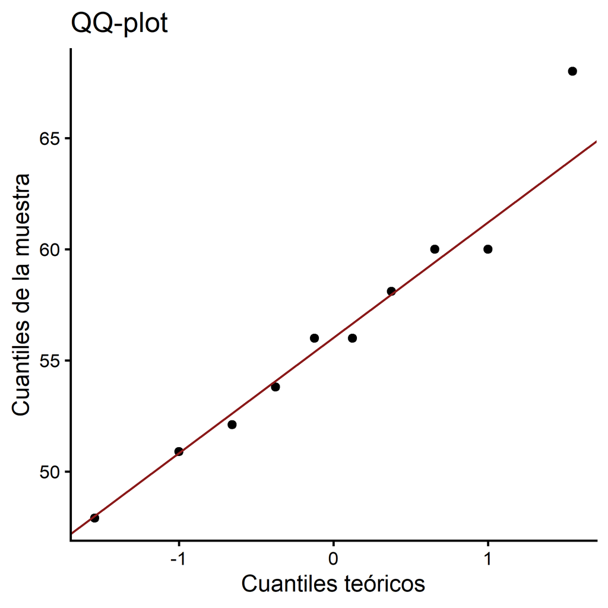

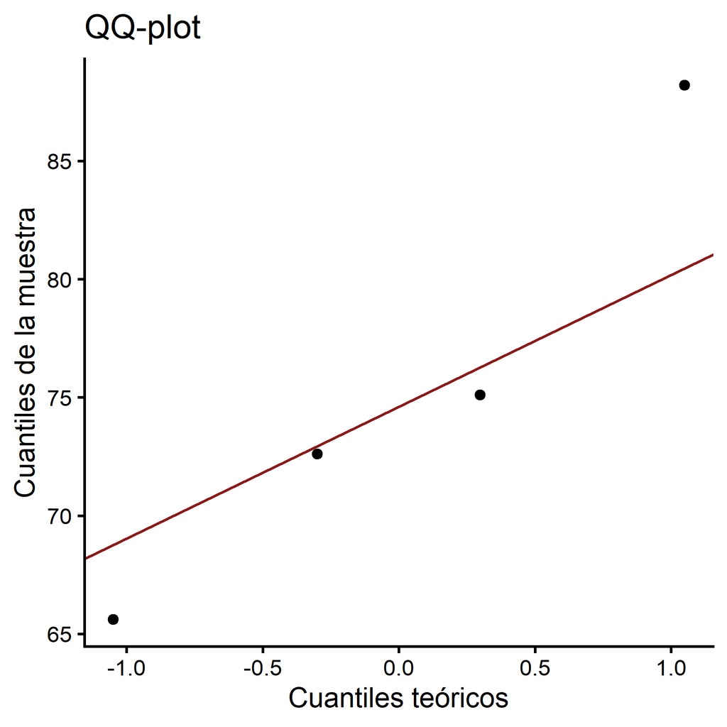

```r
QQ_plot(controles)
QQ_plot(sinestesicos)
```

```r
# homogeneidad de varianzas
leveneTest(score ~ group, data = sinestesia)
```

```
## Levene's Test for Homogeneity of Variance (center = median)
##       Df F value Pr(>F)
## group  1  0.6504 0.4357
##       12
```

```r
# t-test
t.test(score ~ group, data = sinestesia, var.equal = TRUE)
```

```
##
##  Two Sample t-test
##
## data:  score by group
## t = -4.7286, df = 12, p-value = 0.0004897
## alternative hypothesis: true difference in means between group controls and group synesthetes is not equal to 0
## 95 percent confidence interval:
##  -27.89352 -10.29648
## sample estimates:
##    mean in group controls mean in group synesthetes
##                    56.280                    75.375
```

- Normalidad: p > 0.05 en los dos grupos (aunque con solo 4 sinestésicos el test tiene muy poca capacidad de detectar desviaciones).
- Levene: p = 0.44, varianzas iguales → `var.equal = TRUE`.
- `t`-test: p = 0.0005 < 0.05. Las personas sinestésicas obtienen una puntuación media mayor (75.4) que los controles (56.3).

```r
# tamaño del efecto
cohens_d(score ~ group, data = sinestesia)
```

```
## Cohen's d |         95% CI
## --------------------------
## -2.80     | [-4.37, -1.16]
##
## - Estimated using pooled SD.
```

```r
d_sin <- cohens_d(score ~ group, data = sinestesia)$Cohens_d

# potencia (usamos n = 4, el grupo más pequeño) y n para una potencia del 80%
power.t.test(n = 4, delta = d_sin, sd = 1)$power
```

```
## [1] 0.9060031
```

```r
power.t.test(delta = d_sin, sd = 1, power = 0.8)$n
```

```
## [1] 3.302648
```

- *d* = −2.80 (negativa porque `R` resta controles − sinestésicos; lo que importa es el valor absoluto): efecto **muy grande**. Las dos distribuciones apenas se solapan.
- Por eso, aun con solo 4 sinestésicos la potencia es alta (≈ 0.91 de forma aproximada, y algo más en realidad, porque el otro grupo tiene 10), y bastan 4 personas (*n* = 3.3) por grupo para una potencia del 80%.

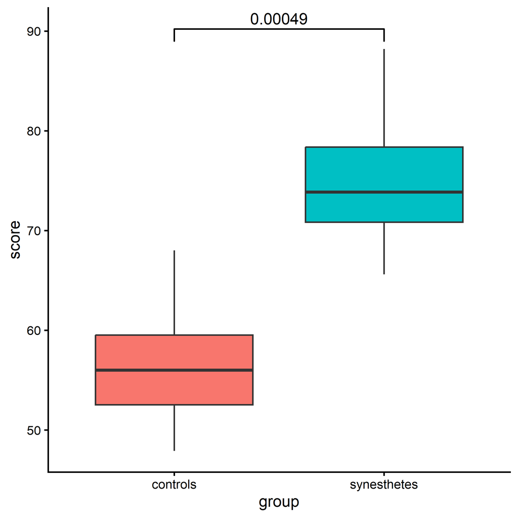

```r
ggplot(sinestesia, aes(x = group, y = score, fill = group)) +
  geom_boxplot() +
  theme_classic() +
  theme(legend.position = "none") +
  geom_signif(comparisons = list(c("controls", "synesthetes")),
              test = "t.test", test.args = list(var.equal = TRUE))
```

### ⏳ ¿Funciona el ayuno intermitente?

```r
monos <- read.table("data/chap02q35FoodReductionLifespan.txt", header = TRUE, sep = "\t")
head(monos)
```

```
##      sex foodTreatment lifespan
## 1 female       reduced     16.5
## 2 female       reduced     18.9
## 3 female       reduced     22.6
## 4 female       reduced     27.8
## 5 female       reduced     30.2
## 6 female       reduced     30.7
```

```r
table(monos$foodTreatment)
```

```
##
## control reduced
##      17      17
```

```r
# comprobación de normalidad (en cada grupo)
control <- monos %>% filter(foodTreatment == "control") %>% pull(lifespan)
reducida <- monos %>% filter(foodTreatment == "reduced") %>% pull(lifespan)
shapiro.test(control)
```

```
##
##  Shapiro-Wilk normality test
##
## data:  control
## W = 0.9123, p-value = 0.1094
```

```r
shapiro.test(reducida)
```

```
##
##  Shapiro-Wilk normality test
##
## data:  reducida
## W = 0.92435, p-value = 0.1749
```

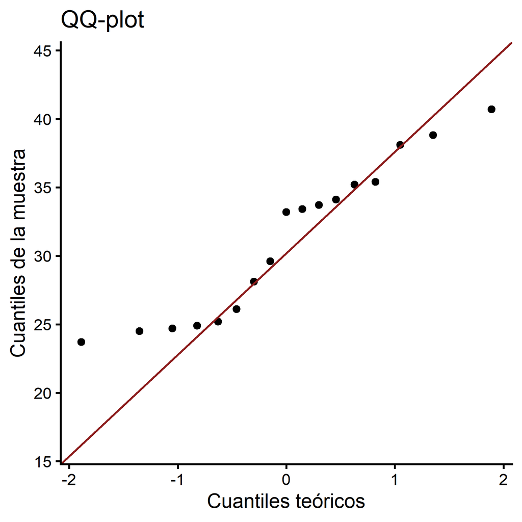

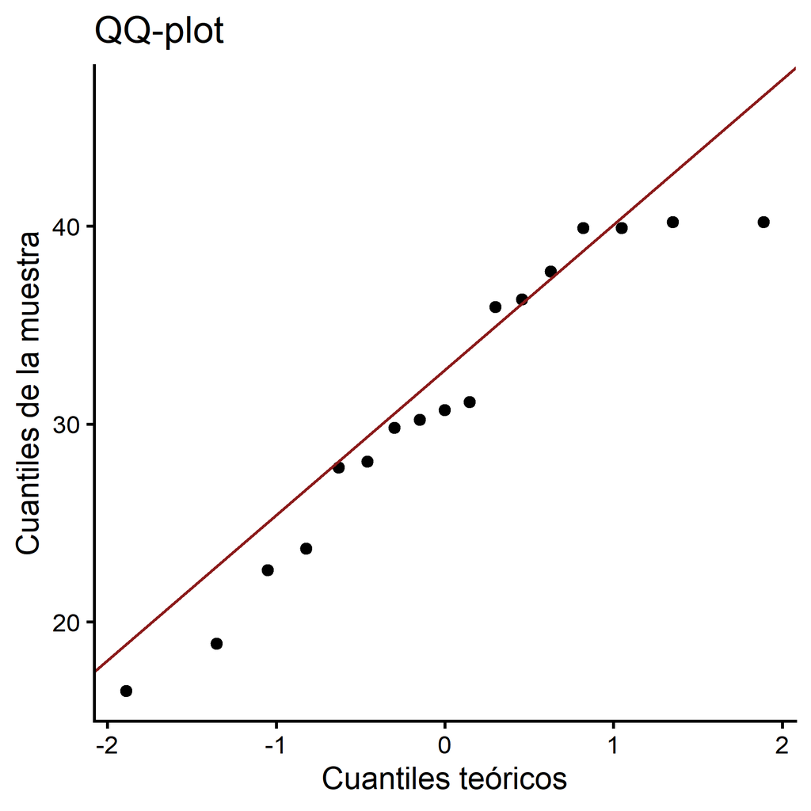

```r
QQ_plot(control)
QQ_plot(reducida)
```

```r
# homogeneidad de varianzas
leveneTest(lifespan ~ foodTreatment, data = monos)
```

```
## Levene's Test for Homogeneity of Variance (center = median)
##       Df F value Pr(>F)
## group  1  0.8676 0.3586
##       32
```

```r
# t-test
t.test(lifespan ~ foodTreatment, data = monos, var.equal = TRUE)
```

```
##
##  Two Sample t-test
##
## data:  lifespan by foodTreatment
## t = -0.0025604, df = 32, p-value = 0.998
## alternative hypothesis: true difference in means between group control and group reduced is not equal to 0
## 95 percent confidence interval:
##  -4.685525  4.673760
## sample estimates:
## mean in group control mean in group reduced
##              31.14118              31.14706
```

- Normalidad: p > 0.05 en los dos grupos. Levene: p = 0.36, varianzas iguales.
- `t`-test: p = 0.998. No rechazamos H₀: no hay evidencia de que la dieta reducida cambie la esperanza de vida (31.1 años en los dos grupos).

```r
# tamaño del efecto
cohens_d(lifespan ~ foodTreatment, data = monos)
```

```
## Cohen's d |        95% CI
## -------------------------
## -8.78e-04 | [-0.67, 0.67]
##
## - Estimated using pooled SD.
```

```r
d_monos <- cohens_d(lifespan ~ foodTreatment, data = monos)$Cohens_d

# potencia y n para una potencia del 80%
power.t.test(n = 17, delta = d_monos, sd = 1)$power
```

```
## [1] 0.02514559
```

```r
power.t.test(delta = d_monos, sd = 1, power = 0.8)$n
```

```
## [1] 20352892
```

- *d* ≈ 0.00: el efecto es **prácticamente cero**. Las medias de los dos grupos difieren menos de una centésima de año. El IC 95% (aproximadamente de −0.67 a 0.67) incluye el 0.
- La potencia (0.025) es tan baja y la *n* necesaria tan absurda (millones de monos) porque **no hay prácticamente ninguna diferencia que detectar**. Aquí el resultado no significativo no se debe a una muestra pequeña: el tamaño del efecto nos dice que la diferencia observada es trivial.

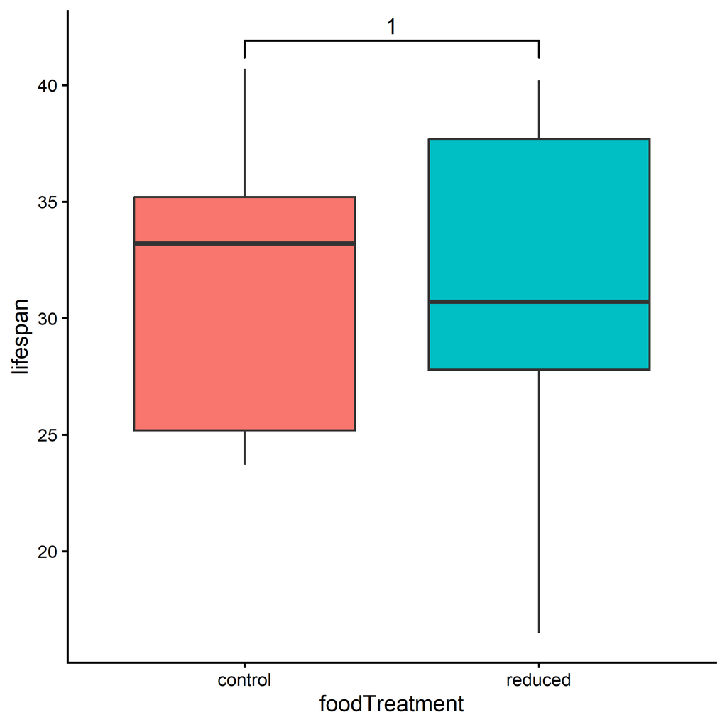

```r
ggplot(monos, aes(x = foodTreatment, y = lifespan, fill = foodTreatment)) +
  geom_boxplot() +
  theme_classic() +
  theme(legend.position = "none") +
  geom_signif(comparisons = list(c("control", "reduced")),
              test = "t.test", test.args = list(var.equal = TRUE))
```

### 💞🧬 ¿Un gen para la monogamia?

```r
topillos <- read.table("data/chap03q15VasopressinVoles.txt", header = TRUE, sep = "\t")
head(topillos)
```

```
##   treatment percent
## 1   control      98
## 2   control      96
## 3   control      94
## 4   control      88
## 5   control      86
## 6   control      82
```

```r
table(topillos$treatment)
```

```
##
##  control enhanced
##       20       11
```

```r
# comprobación de normalidad (en cada grupo)
control_t <- topillos %>% filter(treatment == "control") %>% pull(percent)
enhanced <- topillos %>% filter(treatment == "enhanced") %>% pull(percent)
shapiro.test(control_t)
```

```
##
##  Shapiro-Wilk normality test
##
## data:  control_t
## W = 0.93975, p-value = 0.2372
```

```r
shapiro.test(enhanced)
```

```
##
##  Shapiro-Wilk normality test
##
## data:  enhanced
## W = 0.8817, p-value = 0.1093
```

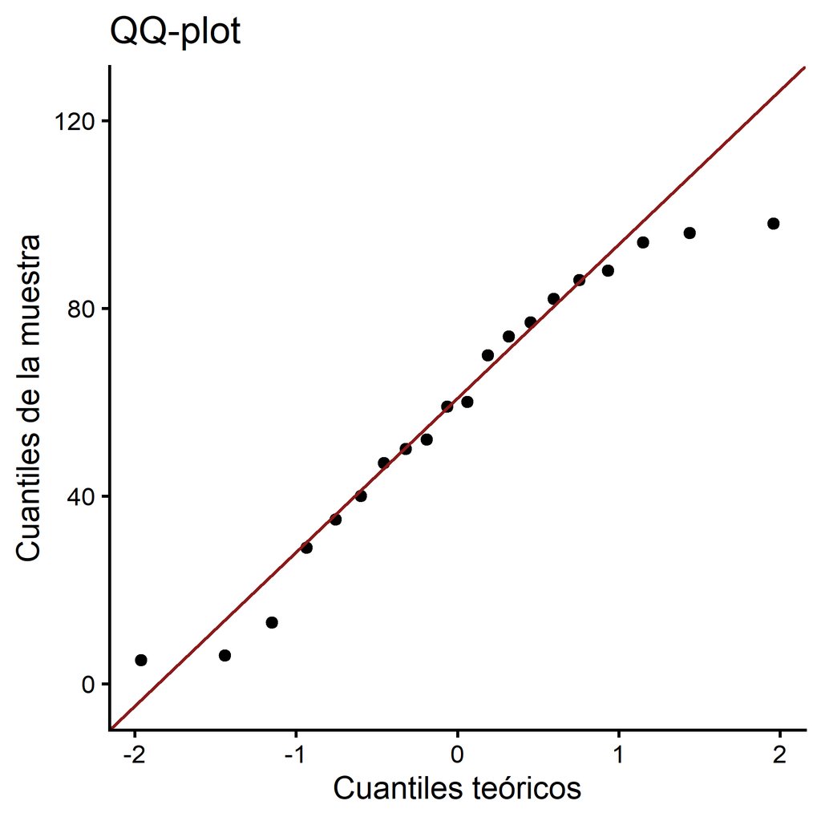

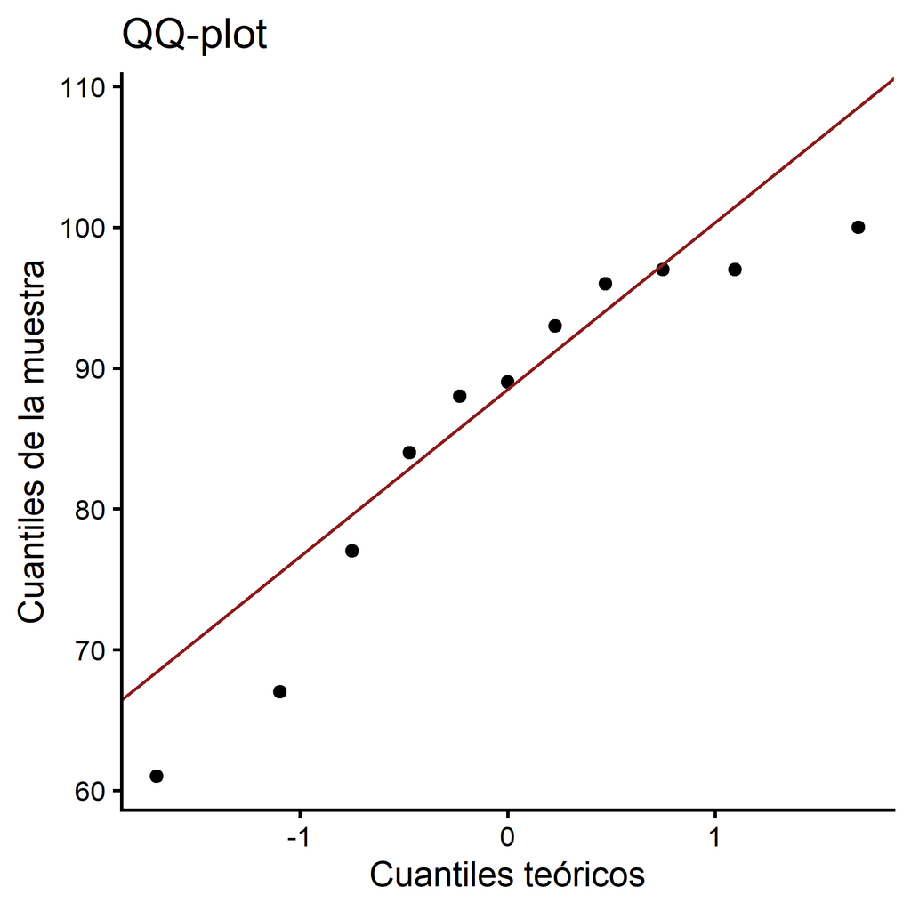

```r
QQ_plot(control_t)
QQ_plot(enhanced)
```

```r
# homogeneidad de varianzas
leveneTest(percent ~ treatment, data = topillos)
```

```
## Levene's Test for Homogeneity of Variance (center = median)
##       Df F value   Pr(>F)
## group  1   8.014 0.008347 **
##       29
## ---
## Signif. codes:  0 '***' 0.001 '**' 0.01 '*' 0.05 '.' 0.1 ' ' 1
```

- Normalidad: Shapiro no la rechaza en ningún grupo (p = 0.24 y p = 0.11), pero son pocos datos y son porcentajes: en el grupo `enhanced` los valores se acumulan cerca del 100% (el máximo posible), y en los QQ-plots los puntos se separan de la recta en los extremos.
- Levene: p = 0.008 < 0.05: las varianzas **no** son iguales. Si hacemos el `t`-test, debe ser el de Welch (`var.equal = FALSE`).

```r
# t-test de Welch
t.test(percent ~ treatment, data = topillos, var.equal = FALSE)
```

```
##
##  Welch Two Sample t-test
##
## data:  percent by treatment
## t = -3.6605, df = 28.009, p-value = 0.001035
## alternative hypothesis: true difference in means between group control and group enhanced is not equal to 0
## 95 percent confidence interval:
##  -44.01568 -12.42977
## sample estimates:
##  mean in group control mean in group enhanced
##               58.05000               86.27273
```

```r
# alternativa no paramétrica
wilcox.test(percent ~ treatment, data = topillos)
```

```
##
##  Wilcoxon rank sum test with continuity correction
##
## data:  percent by treatment
## W = 42.5, p-value = 0.005652
## alternative hypothesis: true location shift is not equal to 0
```

Los dos tests llegan a la misma conclusión (Welch: p = 0.001; Wilcoxon: p = 0.006; ambos < 0.05): los machos con más expresión de V1a pasan más tiempo acurrucados con la hembra (86.3% de media frente a 58.1% en los controles). Es decir, aumentar la expresión de un solo gen hace que una especie promiscua se comporte de forma más monógama.

```r
# tamaño del efecto
cohens_d(percent ~ treatment, data = topillos)
```

```
## Cohen's d |         95% CI
## --------------------------
## -1.12     | [-1.90, -0.32]
##
## - Estimated using pooled SD.
```

```r
d_top <- cohens_d(percent ~ treatment, data = topillos)$Cohens_d

# potencia (usamos n = 11, el grupo más pequeño) y n para una potencia del 80%
power.t.test(n = 11, delta = d_top, sd = 1)$power
```

```
## [1] 0.7033095
```

```r
power.t.test(delta = d_top, sd = 1, power = 0.8)$n
```

```
## [1] 13.59561
```

- *d* = −1.12 (negativa porque `R` resta control − enhanced): efecto **grande**.
- Con 11 topillos en el grupo más pequeño, la potencia aproximada es de 0.70, y harían falta 14 topillos (*n* = 13.6) por grupo para llegar al 80%. (Ojo: como las varianzas son distintas, la *d* calculada con $s_p$ es solo una aproximación.)

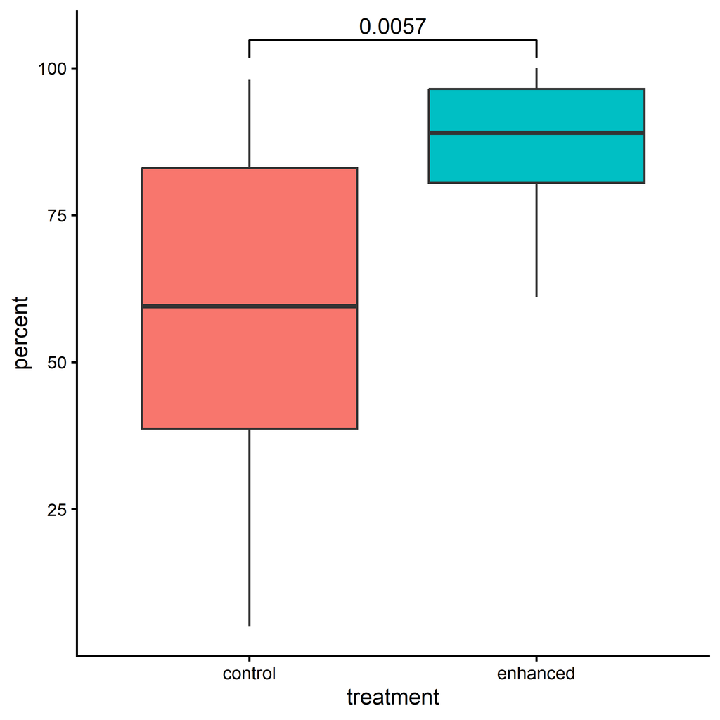

```r
ggplot(topillos, aes(x = treatment, y = percent, fill = treatment)) +
  geom_boxplot() +
  theme_classic() +
  theme(legend.position = "none") +
  geom_signif(comparisons = list(c("control", "enhanced")),
              test = "wilcox.test")
```

### 🕷️💨 Correr con menos peso

```r
aranas <- read.table("data/chap03e2SpiderAmputation.txt", header = TRUE, sep = "\t")
head(aranas)
```

```
##   spider speed treatment
## 1      1  1.25    before
## 2      2  2.94    before
## 3      3  2.38    before
## 4      4  3.09    before
## 5      5  3.41    before
## 6      6  3.00    before
```

```r
# filtra: datos de speed de antes y datos de speed de después
antes_a <- aranas %>% filter(treatment == "before") %>% pull(speed)
despues_a <- aranas %>% filter(treatment == "after") %>% pull(speed)

# calcula las diferencias (después - antes)
diferencias_a <- despues_a - antes_a
diferencias_a
```

```
##  [1] 1.15 0.56 2.11 0.08 1.85 0.22 0.01 0.38 0.72 1.15 2.10 3.42 0.00 0.65 3.08
## [16] 1.49
```

```r
# comprobación de normalidad (de las diferencias)
shapiro.test(diferencias_a)
```

```
##
##  Shapiro-Wilk normality test
##
## data:  diferencias_a
## W = 0.90678, p-value = 0.1033
```

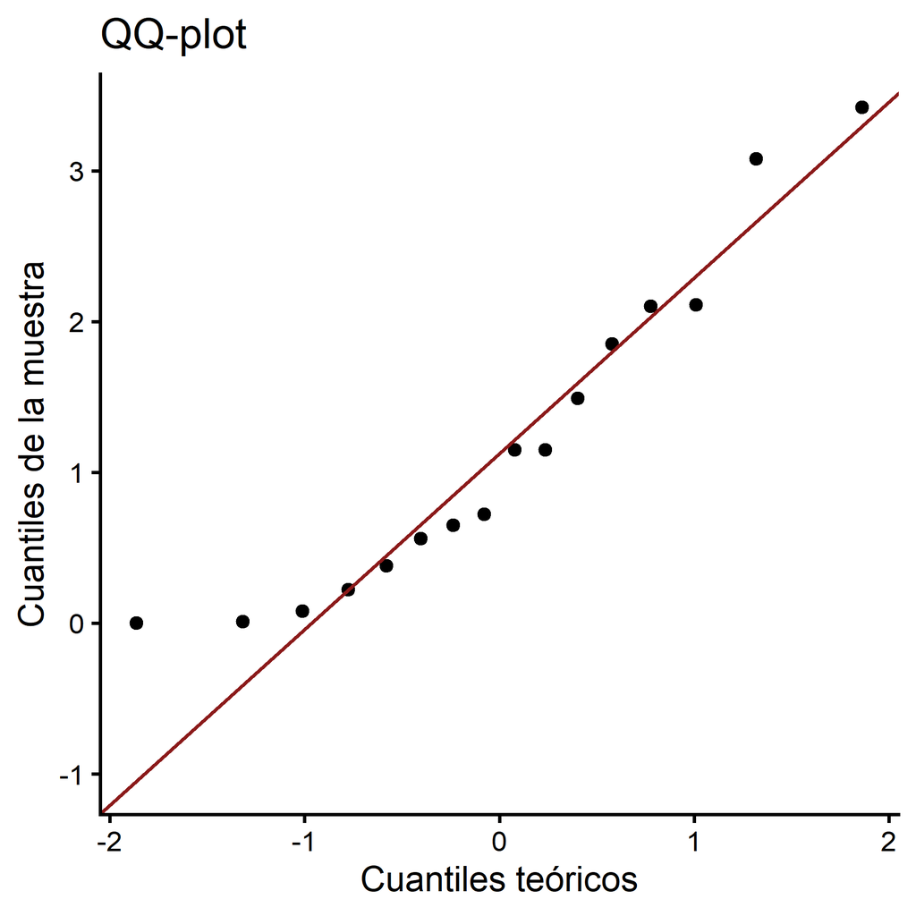

```r
QQ_plot(diferencias_a)
```

```r
# t-test pareado
t.test(despues_a, antes_a, paired = TRUE)
```

```
##
##  Paired t-test
##
## data:  despues_a and antes_a
## t = 4.4166, df = 15, p-value = 5e-04
## alternative hypothesis: true mean difference is not equal to 0
## 95 percent confidence interval:
##  0.613449 1.757801
## sample estimates:
## mean difference
##        1.185625
```

```r
# potencia y n para una potencia del 80%
power.t.test(n = 16, delta = mean(diferencias_a), sd = sd(diferencias_a), type = "paired")$power
```

```
## [1] 0.9845936
```

```r
power.t.test(delta = mean(diferencias_a), sd = sd(diferencias_a), power = 0.8, type = "paired")$n
```

```
## [1] 8.552446
```

- Normalidad de las diferencias: p = 0.10 > 0.05, no la rechazamos.
- `t`-test pareado (bilateral): p = 0.0005 < 0.05. Rechazamos H₀: después de la amputación, los machos corren de media 1.19 cm/s más rápido (IC 95%: 0.61–1.76 cm/s).
- Potencia: con 16 arañas, 0.98. Para una potencia del 80% bastarían **9 arañas** (*n* = 8.55).

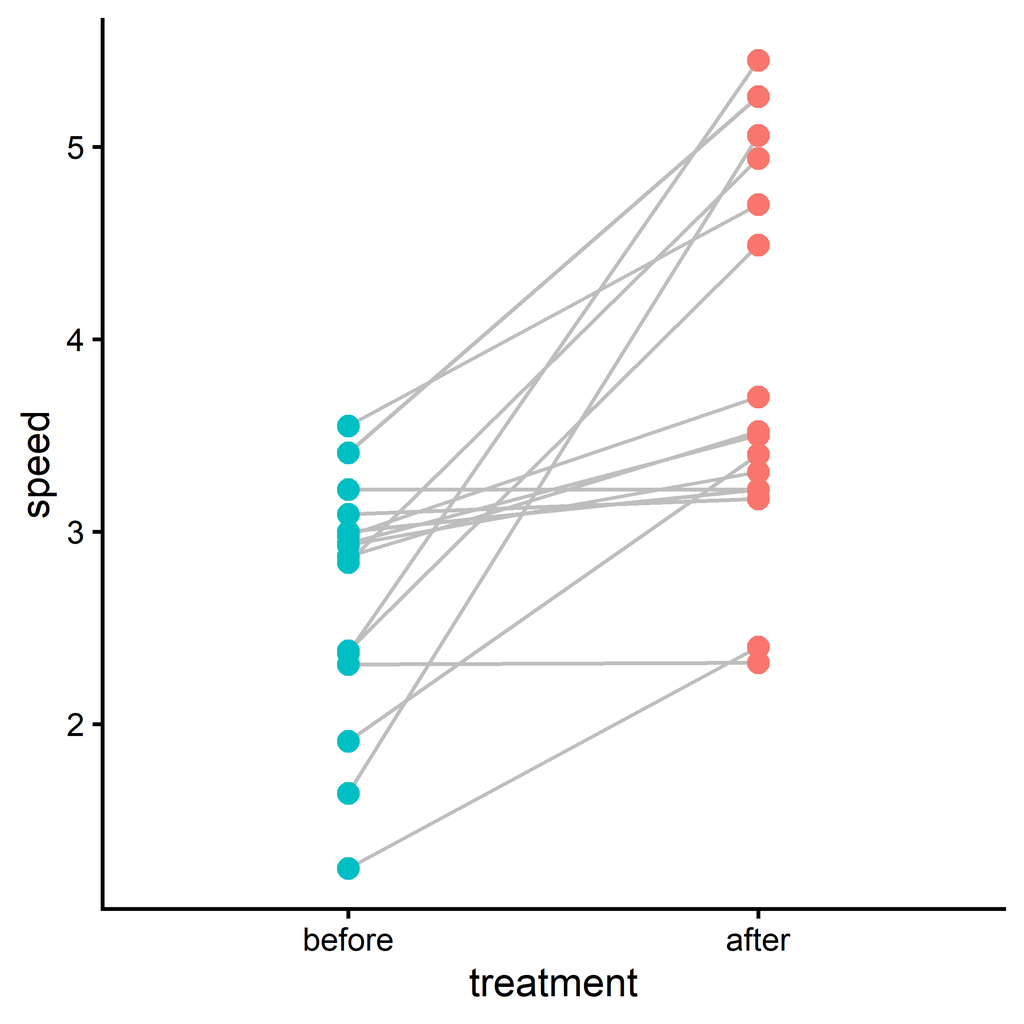

```r
ggplot(aranas, aes(x = treatment, y = speed, group = spider)) +
    geom_line(color = "grey") +
    geom_point(aes(color = treatment), size = 3) +
    theme_classic(base_size = 14) +
    theme(legend.position = "none") +
    scale_x_discrete(limits = c("before", "after"))
```

Con `scale_x_discrete(limits = ...)` ponemos `before` a la izquierda (por defecto, `ggplot2` ordena alfabéticamente y `after` saldría primero). Casi todas las líneas suben: 15 de las 16 arañas corren más rápido después de la amputación.